# Linear Model Summary Figures

# About

All linear models are run, tuned, and saved in their own individual scripts. This quarto doc loads the models and the data that was used in them and then generates figures/tables for individual model outputs or cross-group comparisons.

# Pass 1 Fit

# Pass 1: Model Summary Tables

The following tabs display the summary results from the linear model results from the first pass of analyses. These look at trends and mean differences in annual body size or size spectra among four regions of the Northeast US Continental Shelf.

The acronyms (WS) & (DL) are references to which finfish community is being tested.

**WS**: The “Well Studied” community refers to the 74 species with length-weight relationships published in Wigley et al.

**DL**: The “Data Limited”community refers to the broader finfish group that does not have published/reliable length-weight relationships.

Each table below displays the group level significance, as well as a predictor level significance from an F-Test is shown (uses car::Anova under the hood).

**Bottom Temperature**

| **Characteristic** | **Beta** | **95% CI**<sup>1</sup> | **p-value** |
| --- | --- | --- | --- |
| survey_area |  |  |  |
| GoM | — | — |  |
| GB | 37 | -11, 85 | 0.13 |
| SNE | 49 | 1.5, 97 | 0.043 |
| MAB | 55 | 7.2, 102 | 0.024 |
| season |  |  |  |
| Spring | — | — |  |
| Fall | 16 | -32, 63 | 0.5 |
| yr_num | 0.04 | 0.02, 0.05 | <0.001 |
| survey_area * season |  |  |  |
| GB * Fall | -40 | -108, 28 | 0.2 |
| SNE * Fall | -18 | -86, 50 | 0.6 |
| MAB * Fall | -99 | -166, -31 | 0.004 |
| survey_area * yr_num |  |  |  |
| GB * yr_num | -0.02 | -0.04, 0.01 | 0.13 |
| SNE * yr_num | -0.02 | -0.05, 0.00 | 0.045 |
| MAB * yr_num | -0.03 | -0.05, 0.00 | 0.029 |
| season * yr_num |  |  |  |
| Fall * yr_num | -0.01 | -0.03, 0.02 | 0.5 |
| survey_area * season * yr_num |  |  |  |
| GB * Fall * yr_num | 0.02 | -0.01, 0.06 | 0.2 |
| SNE * Fall * yr_num | 0.01 | -0.02, 0.05 | 0.5 |
| MAB * Fall * yr_num | 0.05 | 0.02, 0.09 | 0.003 |

<sup>1</sup> CI = Confidence Interval

**Median Length (WS)**

| **Characteristic** | **Beta** | **95% CI**<sup>1</sup> | **p-value** |
| --- | --- | --- | --- |
| survey_area |  |  | <0.001 |
| GoM | — | — |  |
| GB | 7.8 | -364, 380 | >0.9 |
| SNE | 102 | -267, 472 | 0.6 |
| MAB | -811 | -1,180, -441 | <0.001 |
| yr_num | -0.16 | -0.29, -0.02 | 0.020 |
| season |  |  | 0.9 |
| Spring | — | — |  |
| Fall | -24 | -394, 345 | 0.9 |
| survey_area * yr_num |  |  | <0.001 |
| GB * yr_num | 0.00 | -0.19, 0.19 | >0.9 |
| SNE * yr_num | -0.05 | -0.24, 0.13 | 0.6 |
| MAB * yr_num | 0.41 | 0.22, 0.59 | <0.001 |
| survey_area * season |  |  | 0.007 |
| GB * Fall | -229 | -754, 297 | 0.4 |
| SNE * Fall | -420 | -946, 105 | 0.12 |
| MAB * Fall | 474 | -52, 999 | 0.077 |
| yr_num * season |  |  | 0.9 |
| yr_num * Fall | 0.01 | -0.17, 0.20 | 0.9 |
| survey_area * yr_num * season |  |  | 0.007 |
| GB * yr_num * Fall | 0.11 | -0.15, 0.37 | 0.4 |
| SNE * yr_num * Fall | 0.20 | -0.06, 0.47 | 0.13 |
| MAB * yr_num * Fall | -0.24 | -0.51, 0.02 | 0.069 |

<sup>1</sup> CI = Confidence Interval

**Median Length (DL))**

| **Characteristic** | **Beta** | **95% CI**<sup>1</sup> | **p-value** |
| --- | --- | --- | --- |
| survey_area |  |  | 0.054 |
| GoM | — | — |  |
| GB | 21 | -257, 300 | 0.9 |
| SNE | 74 | -203, 351 | 0.6 |
| MAB | -281 | -558, -4.4 | 0.046 |
| yr_num | -0.11 | -0.21, -0.01 | 0.026 |
| season |  |  | 0.6 |
| Spring | — | — |  |
| Fall | -83 | -359, 194 | 0.6 |
| survey_area * yr_num |  |  | 0.066 |
| GB * yr_num | -0.01 | -0.15, 0.13 | >0.9 |
| SNE * yr_num | -0.04 | -0.18, 0.10 | 0.6 |
| MAB * yr_num | 0.14 | 0.00, 0.27 | 0.054 |
| survey_area * season |  |  | 0.8 |
| GB * Fall | -24 | -418, 369 | >0.9 |
| SNE * Fall | -49 | -442, 345 | 0.8 |
| MAB * Fall | 126 | -268, 519 | 0.5 |
| yr_num * season |  |  | 0.5 |
| yr_num * Fall | 0.04 | -0.10, 0.18 | 0.5 |
| survey_area * yr_num * season |  |  | 0.8 |
| GB * yr_num * Fall | 0.01 | -0.19, 0.20 | >0.9 |
| SNE * yr_num * Fall | 0.02 | -0.18, 0.21 | 0.9 |
| MAB * yr_num * Fall | -0.07 | -0.26, 0.13 | 0.5 |

<sup>1</sup> CI = Confidence Interval

**Median Weight**

| **Characteristic** | **Beta** | **95% CI**<sup>1</sup> | **p-value** |
| --- | --- | --- | --- |
| survey_area |  |  | <0.001 |
| GoM | — | — |  |
| GB | -5.6 | -21, 9.4 | 0.5 |
| SNE | 4.4 | -10, 19 | 0.6 |
| MAB | -33 | -48, -18 | <0.001 |
| yr_num | -0.01 | -0.01, 0.00 | 0.003 |
| season |  |  | 0.8 |
| Spring | — | — |  |
| Fall | -1.7 | -17, 13 | 0.8 |
| survey_area * yr_num |  |  | <0.001 |
| GB * yr_num | 0.00 | 0.00, 0.01 | 0.4 |
| SNE * yr_num | 0.00 | -0.01, 0.01 | 0.6 |
| MAB * yr_num | 0.02 | 0.01, 0.02 | <0.001 |
| survey_area * season |  |  | 0.012 |
| GB * Fall | -7.5 | -29, 14 | 0.5 |
| SNE * Fall | -17 | -38, 4.1 | 0.11 |
| MAB * Fall | 18 | -3.5, 39 | 0.10 |
| yr_num * season |  |  | 0.8 |
| yr_num * Fall | 0.00 | -0.01, 0.01 | 0.8 |
| survey_area * yr_num * season |  |  | 0.013 |
| GB * yr_num * Fall | 0.00 | -0.01, 0.01 | 0.5 |
| SNE * yr_num * Fall | 0.01 | 0.00, 0.02 | 0.13 |
| MAB * yr_num * Fall | -0.01 | -0.02, 0.00 | 0.090 |

<sup>1</sup> CI = Confidence Interval

**Length Spectra (WS)**

| **Characteristic** | **Beta** | **95% CI**<sup>1</sup> | **p-value** |
| --- | --- | --- | --- |
| survey_area |  |  | <0.001 |
| GoM | — | — |  |
| GB | -0.34 | -7.6, 6.9 | >0.9 |
| SNE | 0.41 | -6.8, 7.7 | >0.9 |
| MAB | -18 | -25, -10 | <0.001 |
| yr_num | 0.00 | -0.01, 0.00 | 0.001 |
| season |  |  | 0.4 |
| Spring | — | — |  |
| Fall | -2.8 | -10, 4.4 | 0.4 |
| survey_area * yr_num |  |  | <0.001 |
| GB * yr_num | 0.00 | 0.00, 0.00 | 0.9 |
| SNE * yr_num | 0.00 | 0.00, 0.00 | >0.9 |
| MAB * yr_num | 0.01 | 0.01, 0.01 | <0.001 |
| survey_area * season |  |  | 0.004 |
| GB * Fall | -2.9 | -13, 7.4 | 0.6 |
| SNE * Fall | -6.8 | -17, 3.5 | 0.2 |
| MAB * Fall | 12 | 1.3, 22 | 0.027 |
| yr_num * season |  |  | 0.4 |
| yr_num * Fall | 0.00 | 0.00, 0.01 | 0.4 |
| survey_area * yr_num * season |  |  | 0.004 |
| GB * yr_num * Fall | 0.00 | 0.00, 0.01 | 0.6 |
| SNE * yr_num * Fall | 0.00 | 0.00, 0.01 | 0.2 |
| MAB * yr_num * Fall | -0.01 | -0.01, 0.00 | 0.021 |

<sup>1</sup> CI = Confidence Interval

**Length Spectra (DL)**

| **Characteristic** | **Beta** | **95% CI**<sup>1</sup> | **p-value** |
| --- | --- | --- | --- |
| survey_area |  |  | 0.005 |
| GoM | — | — |  |
| GB | -0.13 | -7.7, 7.4 | >0.9 |
| SNE | 1.6 | -5.9, 9.2 | 0.7 |
| MAB | -11 | -18, -3.1 | 0.006 |
| yr_num | 0.00 | -0.01, 0.00 | 0.007 |
| season |  |  | 0.3 |
| Spring | — | — |  |
| Fall | -4.1 | -12, 3.4 | 0.3 |
| survey_area * yr_num |  |  | 0.007 |
| GB * yr_num | 0.00 | 0.00, 0.00 | >0.9 |
| SNE * yr_num | 0.00 | 0.00, 0.00 | 0.7 |
| MAB * yr_num | 0.01 | 0.00, 0.01 | 0.007 |
| survey_area * season |  |  | 0.8 |
| GB * Fall | 2.1 | -8.6, 13 | 0.7 |
| SNE * Fall | 5.2 | -5.5, 16 | 0.3 |
| MAB * Fall | 4.5 | -6.2, 15 | 0.4 |
| yr_num * season |  |  | 0.3 |
| yr_num * Fall | 0.00 | 0.00, 0.01 | 0.3 |
| survey_area * yr_num * season |  |  | 0.7 |
| GB * yr_num * Fall | 0.00 | -0.01, 0.00 | 0.7 |
| SNE * yr_num * Fall | 0.00 | -0.01, 0.00 | 0.3 |
| MAB * yr_num * Fall | 0.00 | -0.01, 0.00 | 0.4 |

<sup>1</sup> CI = Confidence Interval

**Mass Spectra**

| **Characteristic** | **Beta** | **95% CI**<sup>1</sup> | **p-value** |
| --- | --- | --- | --- |
| survey_area |  |  | <0.001 |
| GoM | — | — |  |
| GB | -1.3 | -4.9, 2.3 | 0.5 |
| SNE | -1.3 | -4.8, 2.3 | 0.5 |
| MAB | -9.9 | -13, -6.4 | <0.001 |
| yr_num | 0.00 | 0.00, 0.00 | 0.001 |
| season |  |  | 0.5 |
| Spring | — | — |  |
| Fall | -1.2 | -4.7, 2.3 | 0.5 |
| survey_area * yr_num |  |  | <0.001 |
| GB * yr_num | 0.00 | 0.00, 0.00 | 0.4 |
| SNE * yr_num | 0.00 | 0.00, 0.00 | 0.5 |
| MAB * yr_num | 0.00 | 0.00, 0.01 | <0.001 |
| survey_area * season |  |  | 0.002 |
| GB * Fall | -1.4 | -6.4, 3.6 | 0.6 |
| SNE * Fall | -1.3 | -6.4, 3.7 | 0.6 |
| MAB * Fall | 7.3 | 2.3, 12 | 0.005 |
| yr_num * season |  |  | 0.5 |
| yr_num * Fall | 0.00 | 0.00, 0.00 | 0.5 |
| survey_area * yr_num * season |  |  | 0.001 |
| GB * yr_num * Fall | 0.00 | 0.00, 0.00 | 0.6 |
| SNE * yr_num * Fall | 0.00 | 0.00, 0.00 | 0.7 |
| MAB * yr_num * Fall | 0.00 | -0.01, 0.00 | 0.003 |

<sup>1</sup> CI = Confidence Interval

# Pass 1: Marginal Means

**Bottom Temperature**

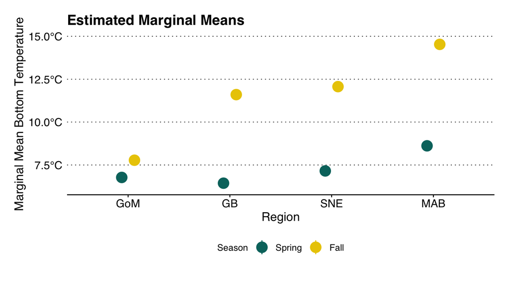

Bottom Temperature EMMeans

| survey_area | emmean | SE | df | lower.CL | upper.CL |
| --- | --- | --- | --- | --- | --- |
| GoM | 7.275 | 0.088 | 380 | 7.102 | 7.447 |
| GB | 9.019 | 0.089 | 380 | 8.845 | 9.194 |
| SNE | 9.610 | 0.088 | 380 | 9.437 | 9.783 |
| MAB | 11.573 | 0.088 | 380 | 11.400 | 11.746 |

Bottom Temperature Pairwise Post-Hoc

| 1 | estimate | SE | df | t.ratio | p.value |
| --- | --- | --- | --- | --- | --- |
| GoM Spring - GB Spring | 0.336 | 0.176 | 380 | 1.905 | 0.548 |
| GoM Spring - SNE Spring | -0.379 | 0.175 | 380 | -2.163 | 0.377 |
| GoM Spring - MAB Spring | -1.843 | 0.175 | 380 | -10.514 | 0.000 |
| GoM Spring - GoM Fall | -1.003 | 0.175 | 380 | -5.723 | 0.000 |
| GoM Spring - GB Fall | -4.828 | 0.176 | 380 | -27.406 | 0.000 |
| GoM Spring - SNE Fall | -5.294 | 0.176 | 380 | -30.050 | 0.000 |
| GoM Spring - MAB Fall | -7.757 | 0.176 | 380 | -44.026 | 0.000 |
| GB Spring - SNE Spring | -0.715 | 0.176 | 380 | -4.058 | 0.002 |
| GB Spring - MAB Spring | -2.179 | 0.176 | 380 | -12.366 | 0.000 |
| GB Spring - GoM Fall | -1.339 | 0.176 | 380 | -7.599 | 0.000 |
| GB Spring - GB Fall | -5.164 | 0.177 | 380 | -29.165 | 0.000 |
| GB Spring - SNE Fall | -5.630 | 0.177 | 380 | -31.795 | 0.000 |
| GB Spring - MAB Fall | -8.092 | 0.177 | 380 | -45.702 | 0.000 |
| SNE Spring - MAB Spring | -1.464 | 0.175 | 380 | -8.351 | 0.000 |
| SNE Spring - GoM Fall | -0.624 | 0.175 | 380 | -3.560 | 0.010 |
| SNE Spring - GB Fall | -4.449 | 0.176 | 380 | -25.254 | 0.000 |
| SNE Spring - SNE Fall | -4.915 | 0.176 | 380 | -27.898 | 0.000 |
| SNE Spring - MAB Fall | -7.378 | 0.176 | 380 | -41.874 | 0.000 |
| MAB Spring - GoM Fall | 0.840 | 0.175 | 380 | 4.791 | 0.000 |
| MAB Spring - GB Fall | -2.985 | 0.176 | 380 | -16.945 | 0.000 |
| MAB Spring - SNE Fall | -3.451 | 0.176 | 380 | -19.589 | 0.000 |
| MAB Spring - MAB Fall | -5.914 | 0.176 | 380 | -33.566 | 0.000 |
| GoM Fall - GB Fall | -3.825 | 0.176 | 380 | -21.712 | 0.000 |
| GoM Fall - SNE Fall | -4.291 | 0.176 | 380 | -24.356 | 0.000 |
| GoM Fall - MAB Fall | -6.754 | 0.176 | 380 | -38.333 | 0.000 |
| GB Fall - SNE Fall | -0.466 | 0.177 | 380 | -2.632 | 0.148 |
| GB Fall - MAB Fall | -2.928 | 0.177 | 380 | -16.539 | 0.000 |
| SNE Fall - MAB Fall | -2.462 | 0.177 | 380 | -13.906 | 0.000 |

**Median Length**

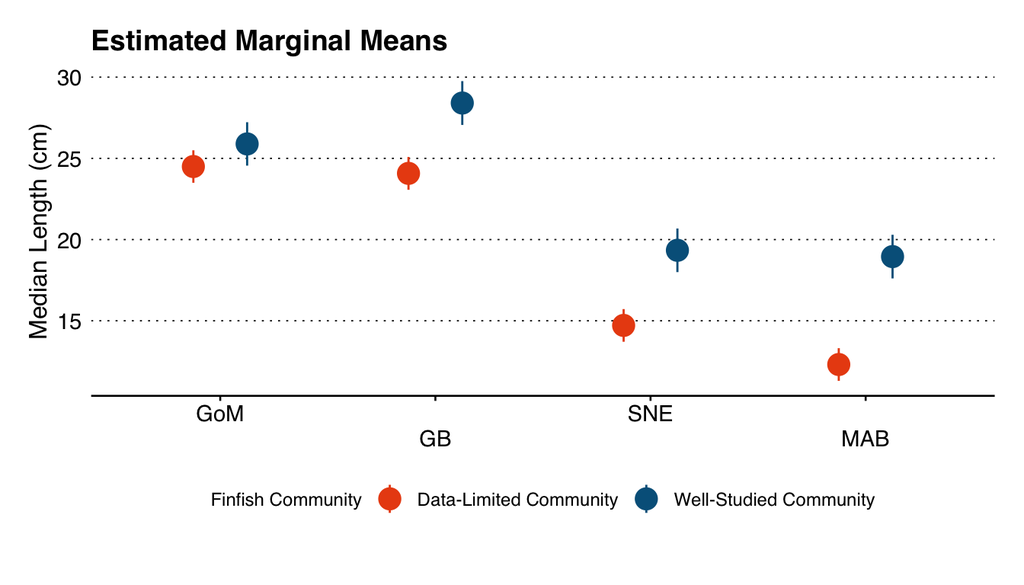

Median Length EMMeans

| survey_area | emmean | SE | df | lower.CL | upper.CL |
| --- | --- | --- | --- | --- | --- |
| Data-Limited Community |  |  |  |  |  |
| GoM | 24.498 | 0.509 | 380 | 23.497 | 25.498 |
| GB | 24.076 | 0.514 | 380 | 23.065 | 25.087 |
| SNE | 14.714 | 0.512 | 380 | 13.708 | 15.720 |
| MAB | 12.307 | 0.512 | 380 | 11.301 | 13.313 |
| Well-Studied Community |  |  |  |  |  |
| GoM | 25.889 | 0.680 | 380 | 24.553 | 27.226 |
| GB | 28.407 | 0.687 | 380 | 27.057 | 29.757 |
| SNE | 19.339 | 0.683 | 380 | 17.996 | 20.683 |
| MAB | 18.952 | 0.683 | 380 | 17.608 | 20.295 |

Median Length Pairwise Post-Hoc

| 1 | estimate | SE | df | t.ratio | p.value |
| --- | --- | --- | --- | --- | --- |
| Data-Limited Community |  |  |  |  |  |
| GoM - GB | 0.422 | 0.723 | 380 | 0.583 | 0.937 |
| GoM - SNE | 9.783 | 0.722 | 380 | 13.559 | 0.000 |
| GoM - MAB | 12.191 | 0.722 | 380 | 16.895 | 0.000 |
| GB - SNE | 9.362 | 0.725 | 380 | 12.909 | 0.000 |
| GB - MAB | 11.769 | 0.725 | 380 | 16.229 | 0.000 |
| SNE - MAB | 2.407 | 0.723 | 380 | 3.327 | 0.005 |
| Well-Studied Community |  |  |  |  |  |
| GoM - GB | -2.518 | 0.966 | 380 | -2.606 | 0.047 |
| GoM - SNE | 6.550 | 0.964 | 380 | 6.797 | 0.000 |
| GoM - MAB | 6.938 | 0.964 | 380 | 7.199 | 0.000 |
| GB - SNE | 9.068 | 0.969 | 380 | 9.362 | 0.000 |
| GB - MAB | 9.455 | 0.969 | 380 | 9.762 | 0.000 |
| SNE - MAB | 0.388 | 0.966 | 380 | 0.401 | 0.978 |

**Median Weight**

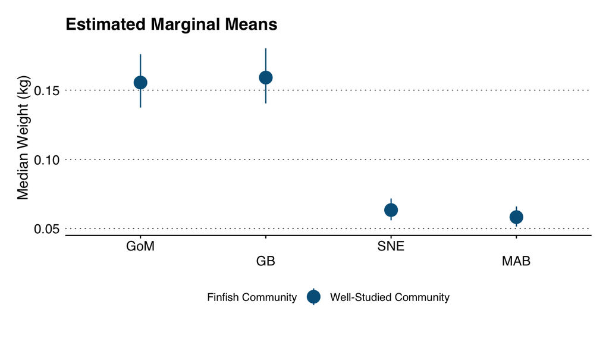

Median Weight EMMeans

| survey_area | response | SE | df | lower.CL | upper.CL |
| --- | --- | --- | --- | --- | --- |
| Well-Studied Community |  |  |  |  |  |
| GoM | 0.155 | 0.010 | 380 | 0.137 | 0.176 |
| GB | 0.159 | 0.010 | 380 | 0.140 | 0.180 |
| SNE | 0.063 | 0.004 | 380 | 0.056 | 0.072 |
| MAB | 0.058 | 0.004 | 380 | 0.051 | 0.066 |

Median Weight Pairwise Post-Hoc

| 1 | ratio | SE | df | null | t.ratio | p.value |
| --- | --- | --- | --- | --- | --- | --- |
| Well-Studied Community |  |  |  |  |  |  |
| GoM / GB | 0.977 | 0.087 | 380 | 1 | -0.254 | 0.994 |
| GoM / SNE | 2.454 | 0.219 | 380 | 1 | 10.055 | 0.000 |
| GoM / MAB | 2.669 | 0.238 | 380 | 1 | 10.995 | 0.000 |
| GB / SNE | 2.511 | 0.225 | 380 | 1 | 10.258 | 0.000 |
| GB / MAB | 2.731 | 0.245 | 380 | 1 | 11.193 | 0.000 |
| SNE / MAB | 1.088 | 0.097 | 380 | 1 | 0.938 | 0.785 |

**Length Spectra**

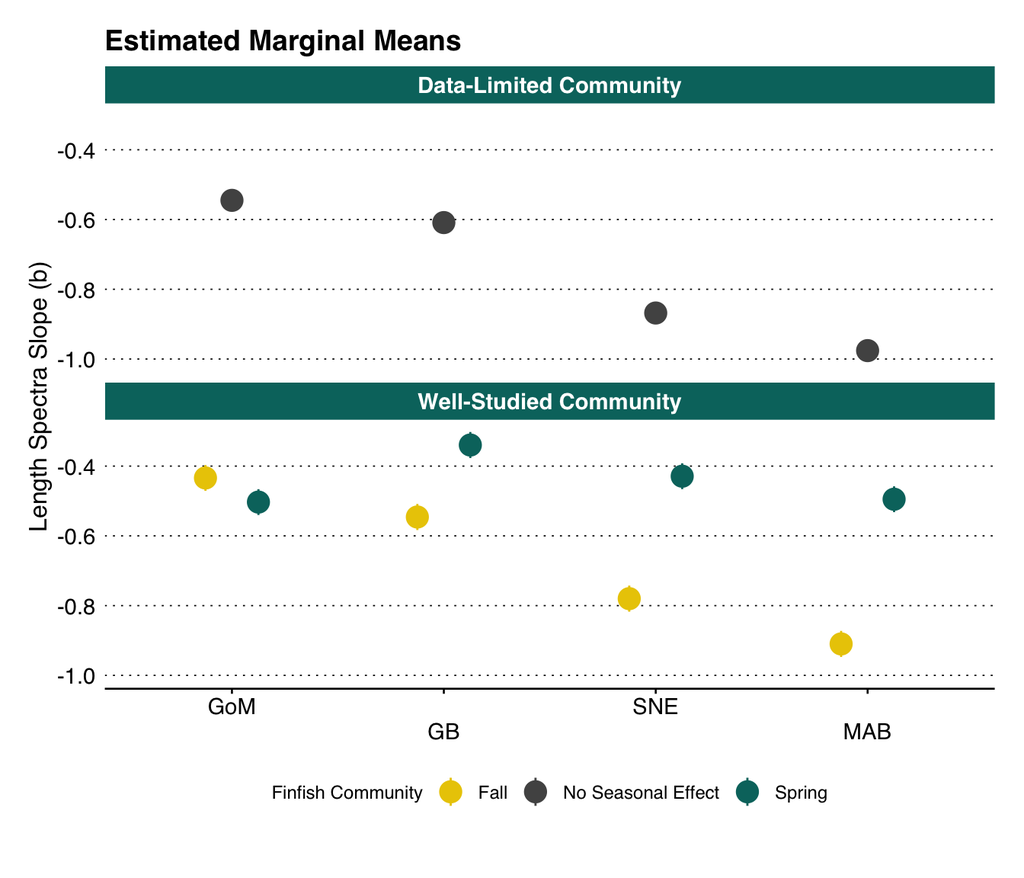

Length Spectra EMMeans

| survey_area | emmean | SE | df | lower.CL | upper.CL | season |
| --- | --- | --- | --- | --- | --- | --- |
| Data-Limited Community |  |  |  |  |  |  |
| GoM | -0.545 | 0.014 | 380 | -0.572 | -0.518 | No Seasonal Effect |
| GB | -0.609 | 0.014 | 380 | -0.636 | -0.581 | No Seasonal Effect |
| SNE | -0.868 | 0.014 | 380 | -0.895 | -0.841 | No Seasonal Effect |
| MAB | -0.976 | 0.014 | 380 | -1.003 | -0.949 | No Seasonal Effect |
| Well-Studied Community |  |  |  |  |  |  |
| GoM | -0.503 | 0.019 | 380 | -0.540 | -0.466 | Spring |
| GB | -0.340 | 0.019 | 380 | -0.377 | -0.302 | Spring |
| SNE | -0.429 | 0.019 | 380 | -0.466 | -0.392 | Spring |
| MAB | -0.495 | 0.019 | 380 | -0.532 | -0.458 | Spring |
| GoM | -0.434 | 0.019 | 380 | -0.471 | -0.397 | Fall |
| GB | -0.546 | 0.019 | 380 | -0.583 | -0.508 | Fall |
| SNE | -0.780 | 0.019 | 380 | -0.817 | -0.743 | Fall |
| MAB | -0.910 | 0.019 | 380 | -0.947 | -0.872 | Fall |

Length Spectra Pairwise Post-Hoc

| 1 | estimate | SE | df | t.ratio | p.value |
| --- | --- | --- | --- | --- | --- |
| Data-Limited Community |  |  |  |  |  |
| GoM - GB | 0.064 | 0.020 | 380 | 3.238 | 0.007 |
| GoM - SNE | 0.323 | 0.020 | 380 | 16.452 | 0.000 |
| GoM - MAB | 0.431 | 0.020 | 380 | 21.945 | 0.000 |
| GB - SNE | 0.259 | 0.020 | 380 | 13.140 | 0.000 |
| GB - MAB | 0.367 | 0.020 | 380 | 18.605 | 0.000 |
| SNE - MAB | 0.108 | 0.020 | 380 | 5.479 | 0.000 |
| Well-Studied Community |  |  |  |  |  |
| GoM Spring - GB Spring | -0.164 | 0.027 | 380 | -6.112 | 0.000 |
| GoM Spring - SNE Spring | -0.074 | 0.027 | 380 | -2.785 | 0.102 |
| GoM Spring - MAB Spring | -0.008 | 0.027 | 380 | -0.308 | 1.000 |
| GoM Spring - GoM Fall | -0.069 | 0.027 | 380 | -2.597 | 0.160 |
| GoM Spring - GB Fall | 0.043 | 0.027 | 380 | 1.596 | 0.753 |
| GoM Spring - SNE Fall | 0.277 | 0.027 | 380 | 10.338 | 0.000 |
| GoM Spring - MAB Fall | 0.407 | 0.027 | 380 | 15.188 | 0.000 |
| GB Spring - SNE Spring | 0.089 | 0.027 | 380 | 3.340 | 0.021 |
| GB Spring - MAB Spring | 0.155 | 0.027 | 380 | 5.806 | 0.000 |
| GB Spring - GoM Fall | 0.094 | 0.027 | 380 | 3.528 | 0.011 |
| GB Spring - GB Fall | 0.206 | 0.027 | 380 | 7.669 | 0.000 |
| GB Spring - SNE Fall | 0.440 | 0.027 | 380 | 16.368 | 0.000 |
| GB Spring - MAB Fall | 0.570 | 0.027 | 380 | 21.193 | 0.000 |
| SNE Spring - MAB Spring | 0.066 | 0.027 | 380 | 2.478 | 0.208 |
| SNE Spring - GoM Fall | 0.005 | 0.027 | 380 | 0.188 | 1.000 |
| SNE Spring - GB Fall | 0.117 | 0.027 | 380 | 4.368 | 0.000 |
| SNE Spring - SNE Fall | 0.351 | 0.027 | 380 | 13.110 | 0.000 |
| SNE Spring - MAB Fall | 0.481 | 0.027 | 380 | 17.959 | 0.000 |
| MAB Spring - GoM Fall | -0.061 | 0.027 | 380 | -2.289 | 0.302 |
| MAB Spring - GB Fall | 0.051 | 0.027 | 380 | 1.902 | 0.550 |
| MAB Spring - SNE Fall | 0.285 | 0.027 | 380 | 10.645 | 0.000 |
| MAB Spring - MAB Fall | 0.415 | 0.027 | 380 | 15.494 | 0.000 |
| GoM Fall - GB Fall | 0.112 | 0.027 | 380 | 4.180 | 0.001 |
| GoM Fall - SNE Fall | 0.346 | 0.027 | 380 | 12.922 | 0.000 |
| GoM Fall - MAB Fall | 0.476 | 0.027 | 380 | 17.772 | 0.000 |
| GB Fall - SNE Fall | 0.234 | 0.027 | 380 | 8.699 | 0.000 |
| GB Fall - MAB Fall | 0.364 | 0.027 | 380 | 13.524 | 0.000 |
| SNE Fall - MAB Fall | 0.130 | 0.027 | 380 | 4.825 | 0.000 |

**Mass Spectra**

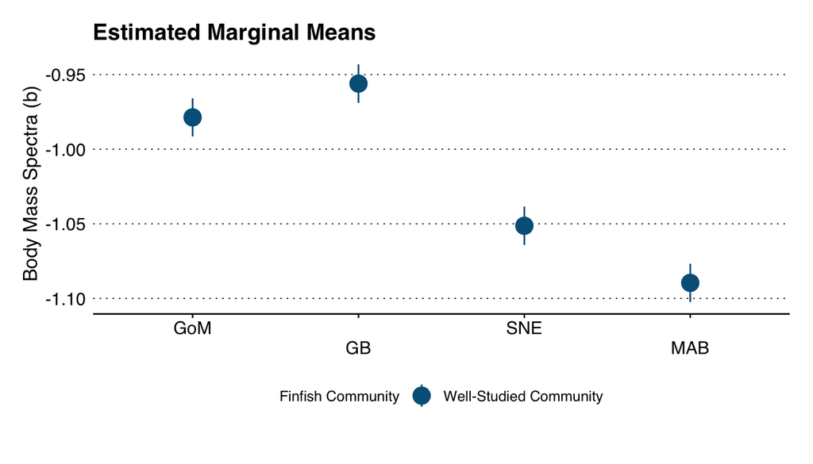

Mass Spectra EMMeans

| survey_area | emmean | SE | df | lower.CL | upper.CL |
| --- | --- | --- | --- | --- | --- |
| Well-Studied Community |  |  |  |  |  |
| GoM | -0.979 | 0.007 | 380 | -0.991 | -0.966 |
| GB | -0.956 | 0.007 | 380 | -0.969 | -0.943 |
| SNE | -1.051 | 0.007 | 380 | -1.064 | -1.038 |
| MAB | -1.090 | 0.007 | 380 | -1.102 | -1.077 |

Mass Spectra Pairwise Post-Hoc

| 1 | estimate | SE | df | t.ratio | p.value |
| --- | --- | --- | --- | --- | --- |
| Well-Studied Community |  |  |  |  |  |
| GoM - GB | -0.023 | 0.009 | 380 | -2.447 | 0.07 |
| GoM - SNE | 0.073 | 0.009 | 380 | 7.880 | 0.00 |
| GoM - MAB | 0.111 | 0.009 | 380 | 12.031 | 0.00 |
| GB - SNE | 0.095 | 0.009 | 380 | 10.282 | 0.00 |
| GB - MAB | 0.134 | 0.009 | 380 | 14.411 | 0.00 |
| SNE - MAB | 0.038 | 0.009 | 380 | 4.140 | 0.00 |

# Pass 1: Marginal Mean Trends

**Bottom Temperature**

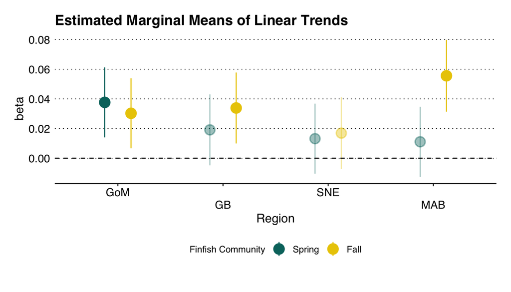

Bottom Temperature EMTrends

| survey_area | season | yr_num.trend | SE | df | lower.CL | upper.CL |
| --- | --- | --- | --- | --- | --- | --- |
| GoM | Spring | 0.038 | 0.009 | 380 | 0.014 | 0.061 |
| GB | Spring | 0.019 | 0.009 | 380 | -0.005 | 0.043 |
| SNE | Spring | 0.013 | 0.009 | 380 | -0.010 | 0.037 |
| MAB | Spring | 0.011 | 0.009 | 380 | -0.013 | 0.035 |
| GoM | Fall | 0.030 | 0.009 | 380 | 0.007 | 0.054 |
| GB | Fall | 0.034 | 0.009 | 380 | 0.010 | 0.058 |
| SNE | Fall | 0.017 | 0.009 | 380 | -0.007 | 0.041 |
| MAB | Fall | 0.056 | 0.009 | 380 | 0.031 | 0.080 |

**Median Length**

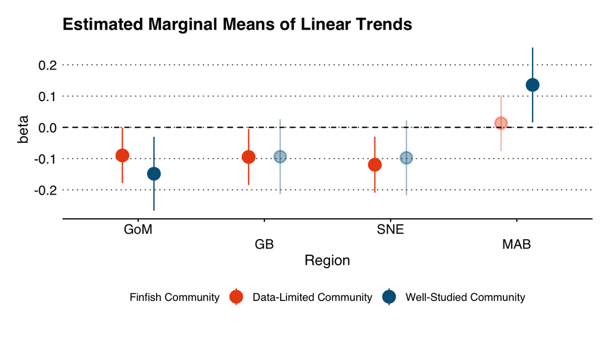

Median Length EMTrends

| survey_area | yr_num.trend | SE | df | lower.CL | upper.CL |
| --- | --- | --- | --- | --- | --- |
| Data-Limited Community |  |  |  |  |  |
| GoM | -0.090 | 0.035 | 380 | -0.178 | -0.001 |
| GB | -0.095 | 0.036 | 380 | -0.184 | -0.005 |
| SNE | -0.120 | 0.036 | 380 | -0.209 | -0.030 |
| MAB | 0.013 | 0.036 | 380 | -0.076 | 0.103 |
| Well-Studied Community |  |  |  |  |  |
| GoM | -0.149 | 0.047 | 380 | -0.267 | -0.030 |
| GB | -0.094 | 0.048 | 380 | -0.214 | 0.026 |
| SNE | -0.098 | 0.048 | 380 | -0.217 | 0.022 |
| MAB | 0.136 | 0.048 | 380 | 0.016 | 0.256 |

**Median Weight**

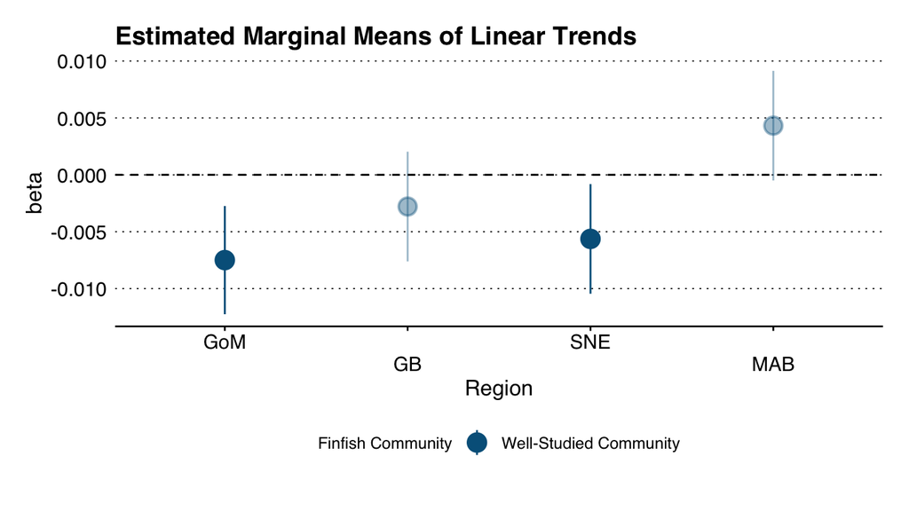

Median Weight EMTrends

| survey_area | yr_num.trend | SE | df | lower.CL | upper.CL |
| --- | --- | --- | --- | --- | --- |
| Well-Studied Community |  |  |  |  |  |
| GoM | -0.007 | 0.002 | 380 | -0.012 | -0.003 |
| GB | -0.003 | 0.002 | 380 | -0.008 | 0.002 |
| SNE | -0.006 | 0.002 | 380 | -0.010 | -0.001 |
| MAB | 0.004 | 0.002 | 380 | 0.000 | 0.009 |

**Length Spectra**

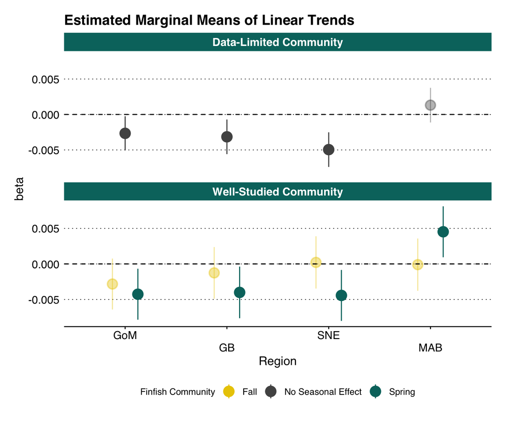

Length Spectra EMTrends

| survey_area | yr_num.trend | SE | df | lower.CL | upper.CL | season |
| --- | --- | --- | --- | --- | --- | --- |
| Data-Limited Community |  |  |  |  |  |  |
| GoM | -0.003 | 0.001 | 380 | -0.005 | 0.000 | No Seasonal Effect |
| GB | -0.003 | 0.001 | 380 | -0.006 | -0.001 | No Seasonal Effect |
| SNE | -0.005 | 0.001 | 380 | -0.007 | -0.003 | No Seasonal Effect |
| MAB | 0.001 | 0.001 | 380 | -0.001 | 0.004 | No Seasonal Effect |
| Well-Studied Community |  |  |  |  |  |  |
| GoM | -0.004 | 0.001 | 380 | -0.008 | -0.001 | Spring |
| GB | -0.004 | 0.001 | 380 | -0.008 | 0.000 | Spring |
| SNE | -0.004 | 0.001 | 380 | -0.008 | -0.001 | Spring |
| MAB | 0.005 | 0.001 | 380 | 0.001 | 0.008 | Spring |
| GoM | -0.003 | 0.001 | 380 | -0.006 | 0.001 | Fall |
| GB | -0.001 | 0.001 | 380 | -0.005 | 0.002 | Fall |
| SNE | 0.000 | 0.001 | 380 | -0.003 | 0.004 | Fall |
| MAB | 0.000 | 0.001 | 380 | -0.004 | 0.004 | Fall |

**Mass Spectra**

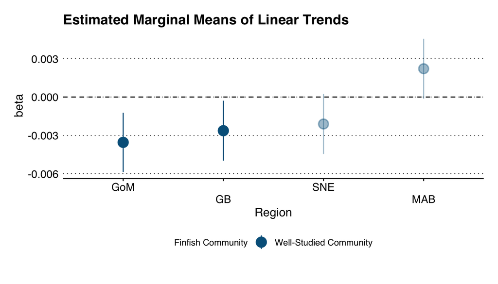

Mass Spectra EMTrends

| survey_area | yr_num.trend | SE | df | lower.CL | upper.CL |
| --- | --- | --- | --- | --- | --- |
| Well-Studied Community |  |  |  |  |  |
| GoM | -0.004 | 0.001 | 380 | -0.006 | -0.001 |
| GB | -0.003 | 0.001 | 380 | -0.005 | 0.000 |
| SNE | -0.002 | 0.001 | 380 | -0.004 | 0.000 |
| MAB | 0.002 | 0.001 | 380 | 0.000 | 0.005 |

# Pass 2: Model summary Tables

The following tabs display the linear model results from the second pass of analyses. These look at the relationships with bottom temperature and landings, and regional differences when accounting for those relationships.

**Median Length (WS)**

| **Characteristic** | **Beta** | **95% CI**<sup>1</sup> | **p-value** |
| --- | --- | --- | --- |
| survey_area |  |  | <0.001 |
| GoM | — | — |  |
| GB | 6.0 | 3.9, 8.0 | <0.001 |
| SNE | -2.8 | -4.9, -0.69 | 0.009 |
| MAB | 0.02 | -2.3, 2.3 | >0.9 |
| log10(landings) | 1.0 | 0.42, 1.7 | 0.001 |
| scale(bot_temp) | -4.7 | -5.5, -3.9 | <0.001 |

<sup>1</sup> CI = Confidence Interval

**Median Length (DL)**

| **Characteristic** | **Beta** | **95% CI**<sup>1</sup> | **p-value** |
| --- | --- | --- | --- |
| survey_area |  |  | <0.001 |
| GoM | — | — |  |
| GB | 2.4 | 0.79, 4.0 | 0.004 |
| SNE | -6.4 | -8.0, -4.8 | <0.001 |
| MAB | -6.0 | -7.9, -4.2 | <0.001 |
| log10(landings) | 0.54 | 0.05, 1.0 | 0.030 |
| scale(bot_temp) | -4.2 | -4.9, -3.6 | <0.001 |

<sup>1</sup> CI = Confidence Interval

**Median Weight**

| **Characteristic** | **Beta** | **95% CI**<sup>1</sup> | **p-value** |
| --- | --- | --- | --- |
| survey_area |  |  | <0.001 |
| GoM | — | — |  |
| GB | 0.36 | 0.16, 0.56 | <0.001 |
| SNE | -0.51 | -0.71, -0.31 | <0.001 |
| MAB | -0.26 | -0.49, -0.04 | 0.019 |
| log10(landings) | 0.08 | 0.02, 0.13 | 0.013 |
| scale(bot_temp) | -0.49 | -0.57, -0.41 | <0.001 |

<sup>1</sup> CI = Confidence Interval

**Length Spectra (WS)**

| **Characteristic** | **Beta** | **95% CI**<sup>1</sup> | **p-value** |
| --- | --- | --- | --- |
| survey_area |  |  | <0.001 |
| GoM | — | — |  |
| GB | 0.13 | 0.09, 0.18 | <0.001 |
| SNE | -0.01 | -0.06, 0.03 | 0.6 |
| MAB | 0.00 | -0.05, 0.04 | 0.8 |
| log10(landings) | 0.02 | 0.01, 0.04 | <0.001 |
| scale(bot_temp) | -0.16 | -0.17, -0.14 | <0.001 |

<sup>1</sup> CI = Confidence Interval

**Length Spectra (DL)**

| **Characteristic** | **Beta** | **95% CI**<sup>1</sup> | **p-value** |
| --- | --- | --- | --- |
| survey_area |  |  | <0.001 |
| GoM | — | — |  |
| GB | 0.05 | 0.01, 0.10 | 0.012 |
| SNE | -0.18 | -0.23, -0.14 | <0.001 |
| MAB | -0.18 | -0.23, -0.13 | <0.001 |
| log10(landings) | 0.03 | 0.01, 0.04 | <0.001 |
| scale(bot_temp) | -0.17 | -0.19, -0.16 | <0.001 |

<sup>1</sup> CI = Confidence Interval

**Mass Spectra**

| **Characteristic** | **Beta** | **95% CI**<sup>1</sup> | **p-value** |
| --- | --- | --- | --- |
| survey_area |  |  | <0.001 |
| GoM | — | — |  |
| GB | 0.07 | 0.05, 0.09 | <0.001 |
| SNE | -0.02 | -0.04, 0.01 | 0.14 |
| MAB | -0.01 | -0.03, 0.02 | 0.6 |
| log10(landings) | 0.01 | 0.00, 0.02 | <0.001 |
| scale(bot_temp) | -0.07 | -0.08, -0.06 | <0.001 |

<sup>1</sup> CI = Confidence Interval

# Pass 2: Effects

**Median Length**

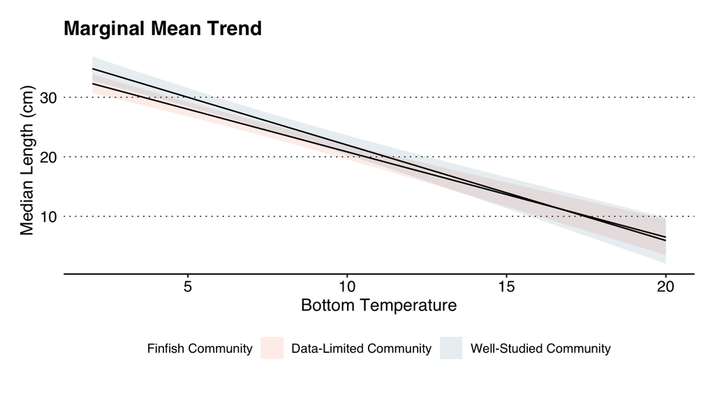

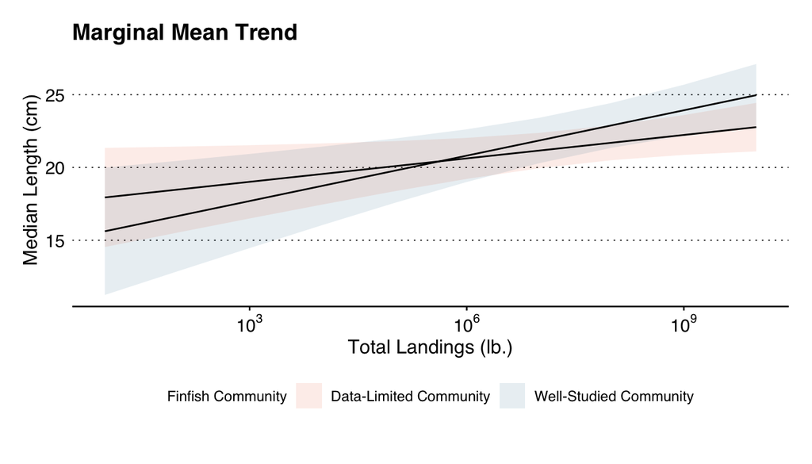

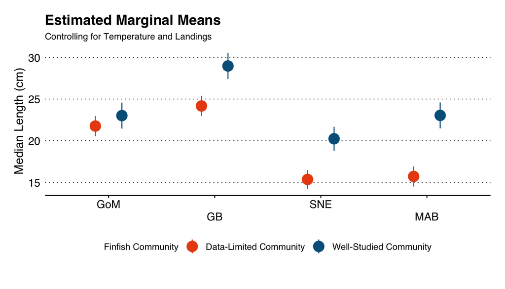

**Median Weight**

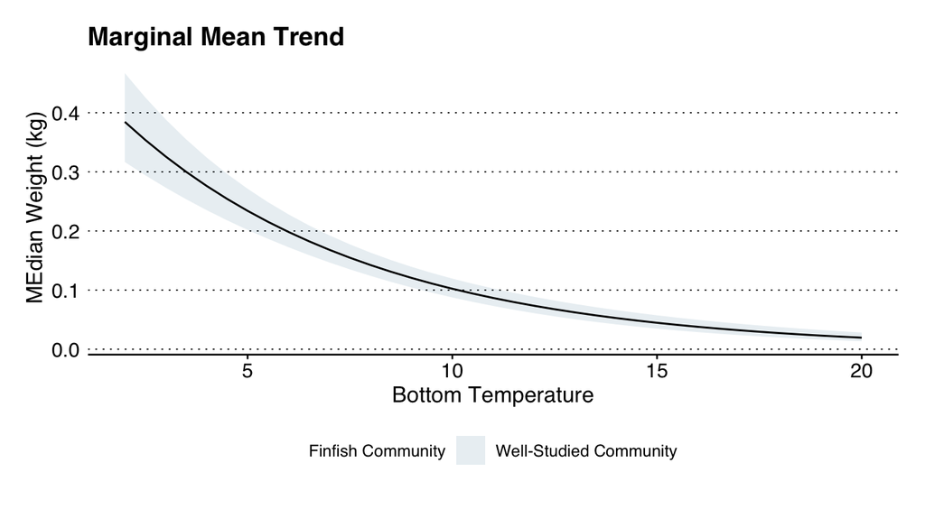

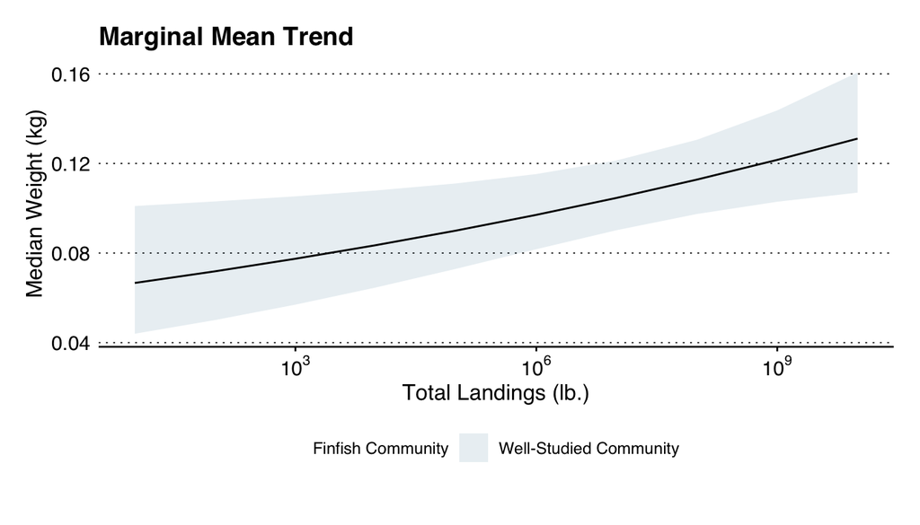

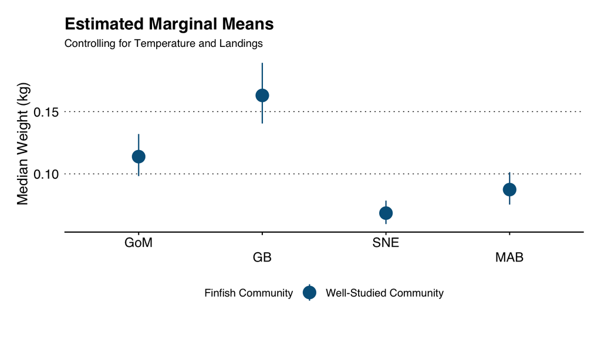

**Length Spectra**

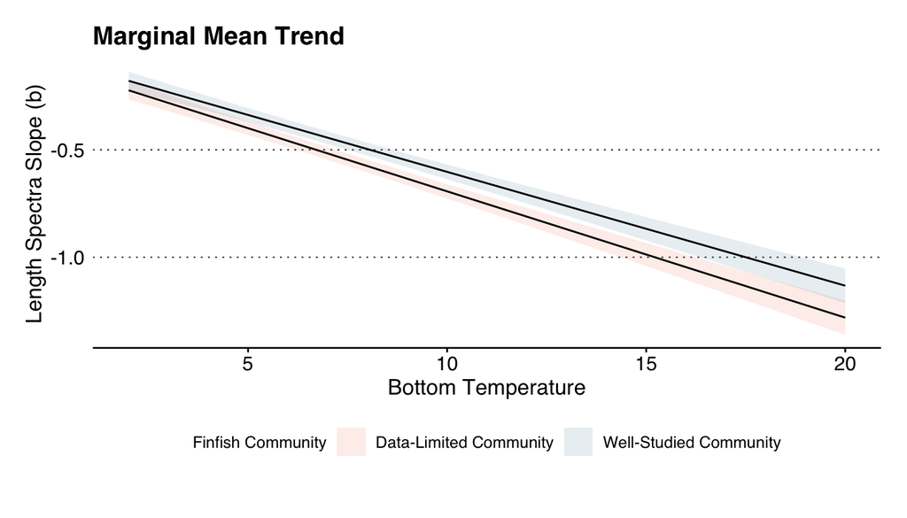

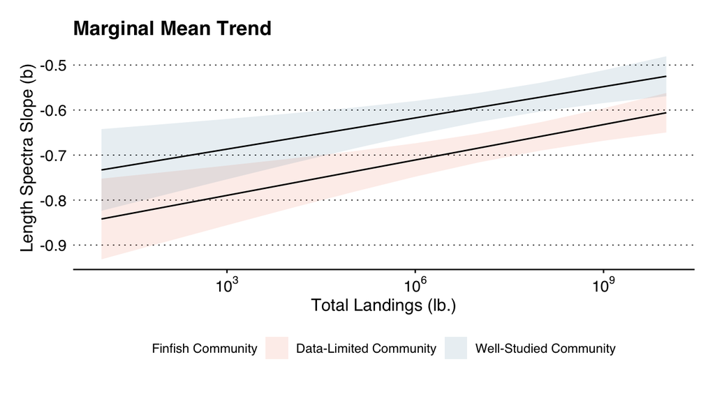

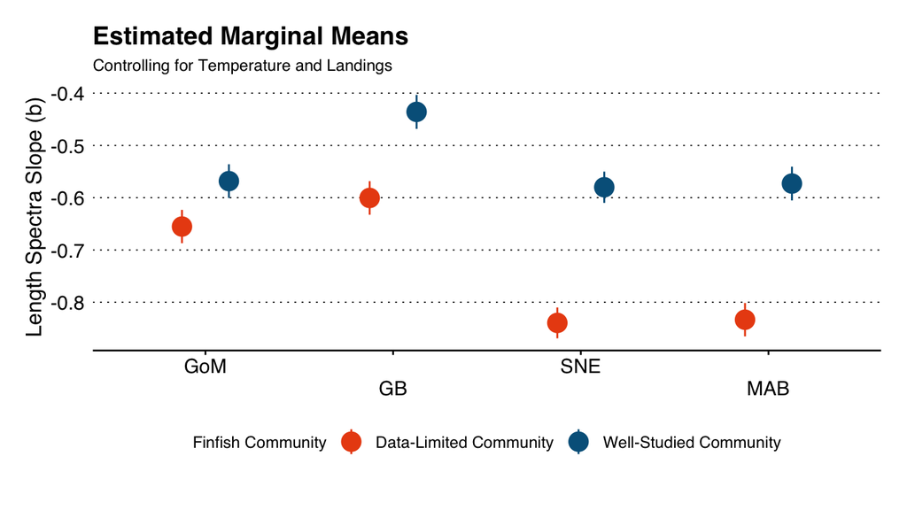

**Mass Spectra**

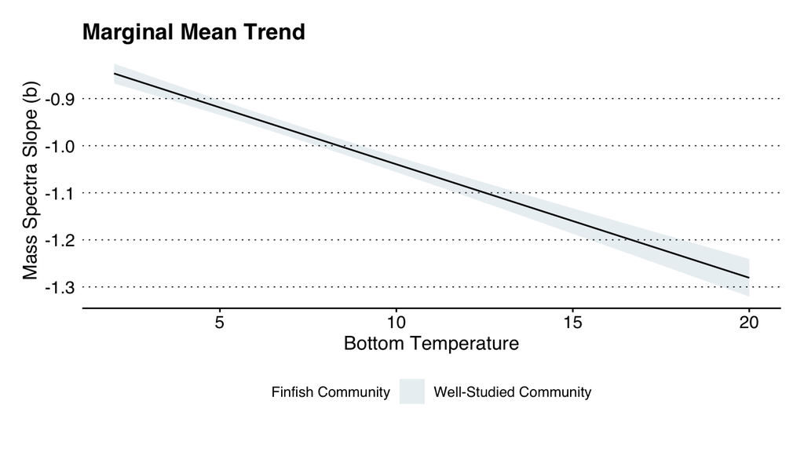

[figure not shown]

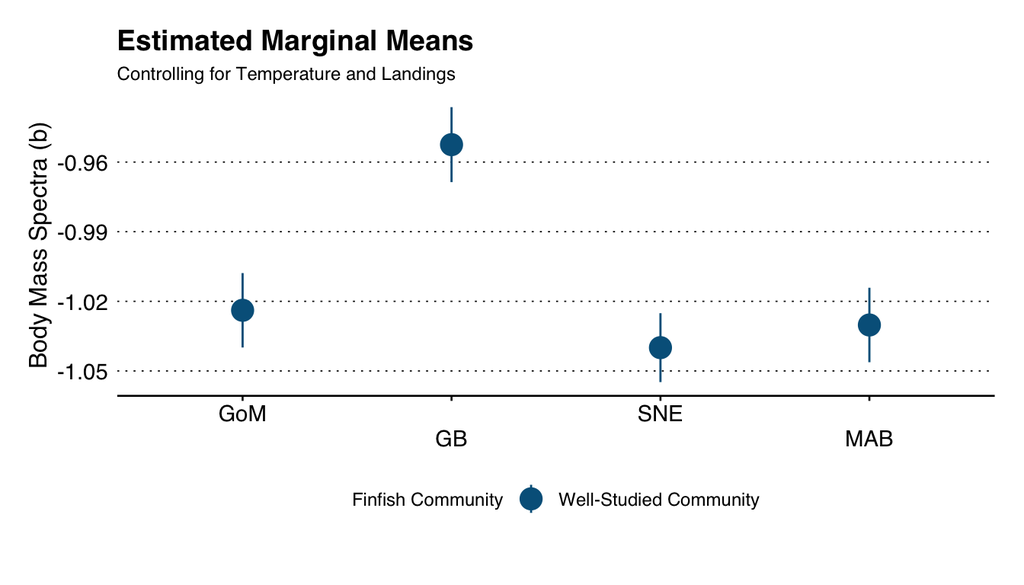

# Comparing Deviance Explained